# Test a Perceptual Phenomenon

## Analyzing the Stroop Effect

In a Stroop task, participants are presented with a list of words, with each word displayed in a color of ink. The participant’s task is to say out loud the color of the ink in which the word is printed. The task has two conditions: a congruent words condition, and an incongruent words condition. In the congruent words condition, the words being displayed are color words whose names match the colors in which they are printed: for example RED, BLUE. In the incongruent words condition, the words displayed are color words whose names do not match the colors in which they are printed: for example PURPLE, ORANGE. In each case, we measure the time it takes to name the ink colors in equally-sized lists. Each participant will go through and record a time from each condition.

## Questions for investigation

### (1) What is the independent variable? What is the dependent variable?

The independent variable is the congruency of the words and the dependent variable is the time it takes to name the colors of the words.

### (2) What is an appropriate set of hypotheses for this task? Specify your null and alternative hypotheses, and clearly define any notation used. Justify your choices.

H0: The means for response times for the two conditions (congruent and incongruent) are the same.

- μ_congruent = μ_incongruent

H1: The means for response times for the two conditions (congruent and incongruent) are not the same.

- μ_congruent ≠ μ_incongruent
- dependent t-test is where you have a crossover design with two different interventions(Congruent and Incongruent) that are both performed by the same participants, so it makes sense to use the dependent t-test as the purpose of this project is to determine whether the population means of the results for the two conditions are different, but the population standard deviations are not known.
- The assumption of the dependent t-test is that the distribution of the differences between the scores of the two related groups needs to be normally distributed. This is an assumption that will be tested once the data is explored further[9].

### (3) Report some descriptive statistics regarding this dataset. Include at least one measure of central tendency and at least one measure of variability. The name of the data file is 'stroopdata.csv'.

```python
# Import Libraries
import pandas as pd
import matplotlib.pyplot as plt
import seaborn as sns
import math
from scipy.stats import t
from scipy import stats
%matplotlib inline
```

```python
# Import dataset
df = pd.read_csv('./stroopdata.csv')
df.describe()
```

|  | Congruent | Incongruent |
| --- | --- | --- |
| count | 24.000000 | 24.000000 |
| mean | 14.051125 | 22.015917 |
| std | 3.559358 | 4.797057 |
| min | 8.630000 | 15.687000 |
| 25% | 11.895250 | 18.716750 |
| 50% | 14.356500 | 21.017500 |
| 75% | 16.200750 | 24.051500 |
| max | 22.328000 | 35.255000 |

- The standard deviation for Incongruent Condition is larger than that of Congruent Condition. Hence, Incongruent distribution is either wider or that there may be outliers.
- Visualisation may provide a clearer reason for that difference.

### (4) Provide one or two visualizations that show the distribution of the sample data. Write one or two sentences noting what you observe about the plot or plots.

#### Visual Analysis with outliers

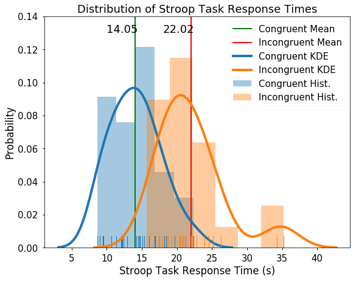

```python
# The following code was written with the aid of the Seaborn[4], MatPlotLib[5].

# Visual Analysis of the Dataset
plt.figure(figsize=(9,7))
sns.set_context("notebook", font_scale=1.5, rc={"lines.linewidth": 2.5})

# Add a vertical line representing the mean for the 'Congruent' condition.
plt.axvline(df['Congruent'].mean(), linewidth=2, color='green', label='Congruent Mean')
plt.annotate(df['Congruent'].mean().round(2), xy=(10, 0.13), xytext=(10, 0.13))

# Add a vertical line representing the mean for the 'Incongruent' condition.
plt.axvline(df['Incongruent'].mean(), linewidth=2, color='red', label='Incongruent Mean')
plt.annotate(df['Incongruent'].mean().round(2), xy=(18, 0.13), xytext=(18, 0.13))

# Plot the distributions for both conditions with histograms, Kernel Density Estimates and rugs.
ax = sns.distplot(df['Congruent'],
                  label='Congruent Hist.',
                  kde=True, rug=True,
                  kde_kws={"lw" : 4, "label": "Congruent KDE"})
ax = sns.distplot(df['Incongruent'],
                  label='Incongruent Hist.',
                  kde=True, rug=True, ax=ax,
                  kde_kws={"lw" : 4, "label": "Incongruent KDE"})

ax.set_title('Distribution of Stroop Task Response Times')
plt.ylim([0,0.14])
plt.xlabel('Stroop Task Response Time (s)')
plt.ylabel('Probability')
plt.legend()
plt.show()
```

- The above distributions show that Incongruent condition has higher reponse times than Congruent condition
- Also there might be two outlier values but they are not far enough from the peak to be clearly distinguished. Further investigation for the outliers is required.

#### Outliers Analysis

```python
outliers = df['Incongruent'][df['Incongruent'] > 30]
no_outliers = df[df['Incongruent'] < 30]

print('How far are the Outliers from the mean of the data With Outliers\n')
print((outliers - df['Incongruent'].mean()) / df['Incongruent'].std())
print('\nHow far are the Outliers from the mean of the data Without Outliers\n')
print((outliers - no_outliers['Incongruent'].mean()) / no_outliers['Incongruent'].std())
```

```
How far are the Outliers from the mean of the data With Outliers

14    2.759834
19    2.558252
Name: Incongruent, dtype: float64

How far are the Outliers from the mean of the data Without Outliers

14    5.004890
19    4.668767
Name: Incongruent, dtype: float64
```

#### Visual Analysis without outliers

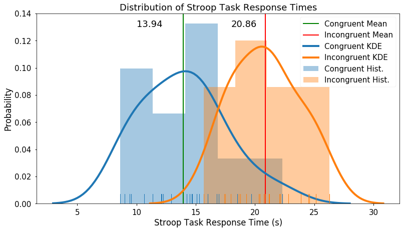

```python
# Visual Analysis of the Dataset
plt.figure(figsize=(13,7))
sns.set_context("notebook", font_scale=1.5, rc={"lines.linewidth": 2.5})

# Add a vertical line representing the mean for the 'Congruent' condition.
plt.axvline(no_outliers['Congruent'].mean(), linewidth=2, color='green', label='Congruent Mean')
plt.annotate(no_outliers['Congruent'].mean().round(2), xy=(10, 0.13), xytext=(10, 0.13))

# Add a vertical line representing the mean for the 'Incongruent' condition.
plt.axvline(no_outliers['Incongruent'].mean(), linewidth=2, color='red', label='Incongruent Mean')
plt.annotate(no_outliers['Incongruent'].mean().round(2), xy=(18, 0.13), xytext=(18, 0.13))

# Plot the distributions for both conditions with histograms, Kernel Density Estimates and rugs.
ax = sns.distplot(no_outliers['Congruent'],
                  label='Congruent Hist.',
                  kde=True, rug=True,
                  kde_kws={"lw" : 4, "label": "Congruent KDE"})
ax = sns.distplot(df['Incongruent'][df['Incongruent'] < 30],
                  label='Incongruent Hist.',
                  kde=True, rug=True, ax=ax,
                  kde_kws={"lw" : 4, "label": "Incongruent KDE"})

ax.set_title('Distribution of Stroop Task Response Times')
plt.ylim([0,0.14])
plt.xlabel('Stroop Task Response Time (s)')
plt.ylabel('Probability')
plt.legend()
plt.show()
```

- The two distributions now are slightly closer and the mean became more inline with the peaks of distributions.

#### Data with outliers

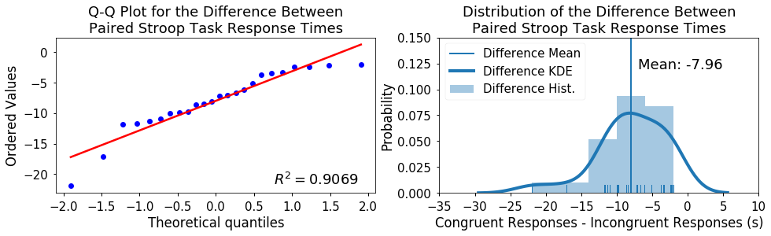

```python
# The following code was written with the aid of the Seaborn[4], MatPlotLib[5] and SciPy[7] API docs.

difference_in_response_time = df['Congruent'] - df['Incongruent']
mean_of_differences = difference_in_response_time.mean()

plt.figure(figsize=(16, 8))

# Q-Q Plot With Outliers.
plt.subplot(2, 2, 1)
stats.probplot(difference_in_response_time, dist="norm", plot=plt, rvalue=True)
plt.title("Q-Q Plot for the Difference Between\nPaired Stroop Task Response Times")

# Distribution Plot With Outliers.
plt.subplot(2, 2, 2)

# Add a vertical line representing the mean of the paired differences.
plt.axvline(x=mean_of_differences, linewidth=2, label='Difference Mean')
plt.annotate(str("Mean: %.2f" % mean_of_differences), xy=(-7, 0.12), xytext=(-7, 0.12))

# Plot the distribution for the paired differences with a histogram, Kernel Density Estimate and rugs.

sns.distplot(difference_in_response_time,
                  label='Difference Hist.',
                  kde=True, rug=True, kde_kws={"lw" : 4, "label": "Difference KDE"})
# Title and label the plot.
plt.title('Distribution of the Difference Between\nPaired Stroop Task Response Times')
plt.xlabel('Congruent Responses - Incongruent Responses (s)')
plt.ylabel('Probability')
plt.xlim([-35, 10])
plt.ylim([0, 0.15])
plt.legend(loc=2)
```

#### Data without outliers

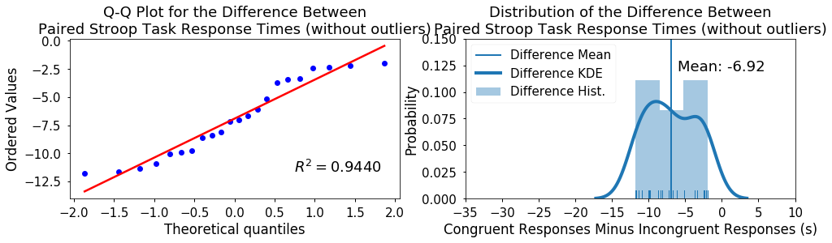

```python
#### PLOTS WITHOUT OUTLIERS
plt.figure(figsize=(16, 8))

# Remove outliers from the data.
difference_in_response_time = no_outliers['Congruent'] - no_outliers['Incongruent']
mean_of_differences = difference_in_response_time.mean()

# Q-Q Plot Without Outliers.
plt.subplot(2, 2, 1)
stats.probplot(difference_in_response_time, dist="norm", plot=plt, rvalue=True)
plt.title("Q-Q Plot for the Difference Between\nPaired Stroop Task Response Times (without outliers)")

# Distribution Plot Without Outliers.
plt.subplot(2, 2, 2)
# Add a vertical line representing the mean of the paired differences.
plt.axvline(x=mean_of_differences, linewidth=2, label='Difference Mean')
plt.annotate(str("Mean: %.2f" % mean_of_differences), xy=(-6, 0.12), xytext=(-6, 0.12))

# Plot the distribution for the paired differences with a histogram, Kernel Density Estimate and rugs.
sns.distplot(difference_in_response_time,
             label='Difference Hist.',
             kde=True, rug=True,
             kde_kws={"lw" : 4, "label": "Difference KDE"})

# Title and label the plot.
plt.title('Distribution of the Difference Between\nPaired Stroop Task Response Times (without outliers)')
plt.xlabel('Congruent Responses Minus Incongruent Responses (s)')
plt.ylabel('Probability')
plt.xlim([-35, 10])
plt.ylim([0, 0.15])
plt.legend(loc=2)
```

- Including outliers show how the oultliers points are far from the regression line.
- Excluding outliers increased the rvalue for the Q-Q plots from 0.9069 to 0.9440.
- The Kernel Density Estimate without outliers is more symetrical.
- Q-Q with rvalue higher than 0.9 suggests that the difference between the response times is modeled by a normal distribution. This fulfills the prerequisite assumption needed to continue with the dependent measures t-test.

### (5) Now, perform the statistical test and report your results. What is your confidence level or Type I error associated with your test? What is your conclusion regarding the hypotheses you set up? Did the results match up with your expectations? **Hint:** Think about what is being measured on each individual, and what statistic best captures how an individual reacts in each environment.

```python
# Perform the statistical test here
def dependent_measures_t_test(data_a, data_b, alpha, t_critical):
    mean_a = data_a.mean()
    mean_b = data_b.mean()
    difference_of_means = mean_a - mean_b

    difference_between_response_times = data_a - data_b

    sample_size = len(data_a)
    df = sample_size - 1

    std_of_the_differences = difference_between_response_times.std()

    t_stat = difference_of_means / (std_of_the_differences / math.sqrt(sample_size))
    p_value = t.pdf(t_stat, df)

    reject_the_null = p_value < alpha

    print ("the alternative hypothesis is accepted? " + str(reject_the_null))
    print ("The p value for a t statistic of " + str(abs(t_stat)) + " with a df of " + str(df) + ": " + str(p_value))

    cohens_d = difference_of_means / std_of_the_differences

    print ("Cohen's D for this test is: " + str(cohens_d))

    ci_lower_boundary = difference_of_means - t_critical * (std_of_the_differences / math.sqrt(sample_size))
    ci_upper_boundary = difference_of_means + t_critical * (std_of_the_differences / math.sqrt(sample_size))

    print ("The confidence interval for a t-critical value of " + str(t_critical) + " is: " +
            "(" + str(ci_lower_boundary) + ", " + str(ci_upper_boundary) + ")")
```

```python
# We are using an alpha level of 0.025 because this is a two tail test.
# T Critical is based on this alpha level and a df of 23
# (based on https://s3.amazonaws.com/udacity-hosted-downloads/t-table.jpg).
t_critical = 2.069
dependent_measures_t_test(df['Congruent'], df['Incongruent'], 0.025, t_critical)
```

```
the alternative hypothesis is accepted? True
The p value for a t statistic of 8.020706944109957 with a df of 23: 4.393995815913909e-08
Cohen's D for this test is: -1.6372199491222625
The confidence interval for a t-critical value of 2.069 is: (-10.019367912023053, -5.91021542131028)
```

```python
# We are using an alpha level of 0.025 because this is a two tail test.
# T Critical is based on this alpha level and a df of 21
# (based on https://s3.amazonaws.com/udacity-hosted-downloads/t-table.jpg).
t_critical = 2.080
dependent_measures_t_test(no_outliers['Congruent'], no_outliers['Incongruent'], 0.025, t_critical)
```

```
the alternative hypothesis is accepted? True
The p value for a t statistic of 9.54109990849218 with a df of 21: 3.957000032377724e-09
Cohen's D for this test is: -2.034169335310982
The confidence interval for a t-critical value of 2.08 is: (-8.425322705004819, -5.409313658631545)
```

- The outliers have much smaller effect on the results than expected, so we will use the entire dataset for any further analysis.
- From this, we can conclude with a 95% degree of confidence that the population mean for the time it takes to complete the Incongruent Stroop Task is at least 5.9102 seconds longer than that for the Congruent Stroop Task.

## Resources

[1] "Dependent T-Test for Paired Samples." Dependent T-Test. Accessed March 30, 2016. https://statistics.laerd.com/statistical-guides/dependent-t-test-statistical-guide.php.

[2] "Dependent T-Test for Paired Samples (cont...)." Dependent T-Test. Accessed March 30, 2016. https://statistics.laerd.com/statistical-guides/dependent-t-test-statistical-guide-2.php.

[3] Waskom, Michael "Seaborn: Statistical Data Visualization." Seaborn: Statistical Data Visualization — Seaborn 0.7.0 Documentation. Accessed March 30, 2016. https://stanford.edu/~mwaskom/software/seaborn/index.html.

[4] Hunter, John, Darren Dale, Eric Firing, Michael Droettboom, and The Matplotlib Development Team. "Introduction." Matplotlib: Python Plotting — Matplotlib 1.5.1 Documentation. Accessed March 30, 2016. http://matplotlib.org/index.html.

[5] Wikipedia contributors, "Kernel density estimation," Wikipedia, The Free Encyclopedia, https://en.wikipedia.org/w/index.php?title=Kernel_density_estimation&oldid=708927254 (accessed March 30, 2016).

[6] The Scipy Community. "SciPy." SciPy — SciPy V0.17.0 Reference Guide. Accessed March 30, 2016. http://docs.scipy.org/doc/scipy/reference/index.html.

[7] Wikipedia contributors, "Q–Q plot," Wikipedia, The Free Encyclopedia, https://en.wikipedia.org/w/index.php?title=Q%E2%80%93Q_plot&oldid=697003051 (accessed March 30, 2016).

[8] Baldo, J. V., Shimamura, A. P., & Prinzmetal, W. (1998). Mapping symbols to response modalities: Interference effects on Stroop-like tasks. Perception and Psychophysics, 60(3), 427–437. https://doi.org/10.3758/BF0320686.

[9] https://statistics.laerd.com/statistical-guides/dependent-t-test-statistical-guide-2.php